# MDR Estadística I

## Boxplot

```python
 # generamos un conjunto de datos aleatorios con distribución normal.
x = np.random.randn(50)
```

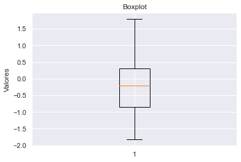

```python
# The error bars indicate 1.5* the inter-quartile-range (IQR), and the box consists of the
# first, second (middle) and third quartile
plt.boxplot(x, sym='o')
plt.title('Boxplot')
plt.ylabel('Valores')
```

```python
## Ejercicio boxplot
## Datos sobre concentración de emaquoiladoras en 43 zonas metropolitanas.

# Make a boxplot  para la distribución del coeficiente de localización entre las 43 ciudades.
## Estime el valor medio, la deviación estandar los percentiles 25 y 75 y el ranfgo intercuartil

metropolitanas=pd.read_csv("https://raw.githubusercontent.com/JoseLuisManzanaresRivera/intersemestral-2021/main/content/post/w.csv", encoding='utf-8')
```

```python
metropolitanas.info()
```

```
<class 'pandas.core.frame.DataFrame'>
RangeIndex: 43 entries, 0 to 42
Data columns (total 8 columns):
 #   Column      Non-Null Count  Dtype
---  ------      --------------  -----
 0   Unnamed: 0  43 non-null     int64
 1   CVE_SUN     43 non-null     int64
 2   ej30        43 non-null     int64
 3   n           43 non-null     float64
 4   e           43 non-null     int64
 5   d           43 non-null     float64
 6   lq          43 non-null     float64
 7   NOM_SUN     43 non-null     object
dtypes: float64(3), int64(4), object(1)
memory usage: 2.8+ KB
```

```python
metropolitanas.head(10)
```

|  | Unnamed: 0 | CVE_SUN | ej30 | n | e | d | lq | NOM_SUN |
| --- | --- | --- | --- | --- | --- | --- | --- | --- |
| 0 | 1 | 57 | 115 | 6.29 | 58661 | 1.10 | 5.70 | Celaya |
| 1 | 2 | 58 | 120 | 6.56 | 64422 | 1.21 | 5.41 | Tianguistenco |
| 2 | 3 | 6 | 46 | 2.52 | 32514 | 0.61 | 4.11 | Monclova-Frontera |
| 3 | 4 | 37 | 50 | 2.73 | 65115 | 1.23 | 2.23 | Canc£n |
| 4 | 5 | 17 | 50 | 2.73 | 68965 | 1.30 | 2.11 | Acapulco |
| 5 | 6 | 52 | 23 | 1.26 | 34920 | 0.66 | 1.91 | Coatzacoalcos |
| 6 | 7 | 2 | 65 | 3.55 | 110356 | 2.08 | 1.71 | Tijuana |
| 7 | 8 | 36 | 62 | 3.39 | 109660 | 2.06 | 1.64 | Querétaro |
| 8 | 9 | 13 | 854 | 46.69 | 1583969 | 29.81 | 1.57 | Valle de MX |
| 9 | 10 | 42 | 33 | 1.80 | 65374 | 1.23 | 1.47 | Tampico |

```python
np.shape(metropolitanas)
```

```
(43, 8)
```

**Solución**

```python
 metropolitanas.describe()
```

|  | Unnamed: 0 | CVE_SUN | ej30 | n | e | d | lq |
| --- | --- | --- | --- | --- | --- | --- | --- |
| count | 43.000000 | 43.000000 | 43.000000 | 43.000000 | 4.300000e+01 | 43.000000 | 43.000000 |
| mean | 22.000000 | 28.418605 | 42.534884 | 2.324884 | 1.179843e+05 | 2.220233 | 1.034651 |
| std | 12.556539 | 17.416785 | 129.774227 | 7.095214 | 2.401780e+05 | 4.520215 | 1.277330 |
| min | 1.000000 | 1.000000 | 2.000000 | 0.110000 | 9.965000e+03 | 0.190000 | 0.080000 |
| 25% | 11.500000 | 13.500000 | 4.500000 | 0.245000 | 3.527450e+04 | 0.665000 | 0.310000 |
| 50% | 22.000000 | 29.000000 | 13.000000 | 0.710000 | 6.449500e+04 | 1.210000 | 0.520000 |
| 75% | 32.500000 | 41.500000 | 37.000000 | 2.020000 | 1.095180e+05 | 2.060000 | 1.295000 |
| max | 43.000000 | 58.000000 | 854.000000 | 46.690000 | 1.583969e+06 | 29.810000 | 5.700000 |

```python
import plotly.express as px

fig = px.box(metropolitanas, y="lq")
fig.show()
```

[interactive chart not shown]

```python
## Box plot para representar la distribución de los registros de temperatura  diarios en cada mes.

dgo_temp=pd.read_csv("https://raw.githubusercontent.com/JoseLuisManzanaresRivera/intersemestral-2021/main/content/post/gogotempe.csv")
```

```python
dgo_temp.info()
```

```
<class 'pandas.core.frame.DataFrame'>
RangeIndex: 15527 entries, 0 to 15526
Data columns (total 10 columns):
 #   Column      Non-Null Count  Dtype
---  ------      --------------  -----
 0   Unnamed: 0  15527 non-null  int64
 1   mes         15527 non-null  object
 2   ms          15527 non-null  int64
 3   FECHA       15527 non-null  object
 4   PRECIPmm    15527 non-null  object
 5   EVAPmm      15527 non-null  object
 6   tmin        15260 non-null  float64
 7   tmax        15260 non-null  float64
 8   date        15527 non-null  object
 9   año         15527 non-null  int64
dtypes: float64(2), int64(3), object(5)
memory usage: 1.2+ MB
```

```python
dgo_temp.head(10)
```

|  | Unnamed: 0 | mes | ms | FECHA | PRECIPmm | EVAPmm | tmin | tmax | date | año |
| --- | --- | --- | --- | --- | --- | --- | --- | --- | --- | --- |
| 0 | 1 | Enero | 1 | 01/01/1941 | 0 | 3.3 | 3.5 | 19.5 | 1941-01-01 | 1941 |
| 1 | 2 | Enero | 1 | 02/01/1941 | 0 | 3.8 | 2.5 | 21.5 | 1941-01-02 | 1941 |
| 2 | 3 | Enero | 1 | 03/01/1941 | 0 | 5.8 | 5.5 | 23.5 | 1941-01-03 | 1941 |
| 3 | 4 | Enero | 1 | 04/01/1941 | 0 | 5.7 | 7.5 | 19.0 | 1941-01-04 | 1941 |
| 4 | 5 | Enero | 1 | 05/01/1941 | 0 | 5 | -4.5 | 21.5 | 1941-01-05 | 1941 |
| 5 | 6 | Enero | 1 | 06/01/1941 | 0 | 4.9 | -2.5 | 23.5 | 1941-01-06 | 1941 |
| 6 | 7 | Enero | 1 | 07/01/1941 | 0 | 8.1 | -3.5 | 23.5 | 1941-01-07 | 1941 |
| 7 | 8 | Enero | 1 | 08/01/1941 | 0 | 5.3 | -1.0 | 24.5 | 1941-01-08 | 1941 |
| 8 | 9 | Enero | 1 | 09/01/1941 | 0.1 | 3.6 | 3.0 | 20.5 | 1941-01-09 | 1941 |
| 9 | 10 | Enero | 1 | 10/01/1941 | 0.2 | 2.9 | 7.0 | 19.0 | 1941-01-10 | 1941 |

```python
np.shape(dgo_temp)
```

```
(15527, 10)
```

```python
dgo_temp.describe()
```

|  | Unnamed: 0 | ms | tmin | tmax | año |
| --- | --- | --- | --- | --- | --- |
| count | 15527.00000 | 15527.000000 | 15260.000000 | 15260.000000 | 15527.000000 |
| mean | 7764.00000 | 6.469634 | 8.156619 | 25.514364 | 1969.162942 |
| std | 4482.40315 | 3.427705 | 5.585651 | 4.540631 | 18.756361 |
| min | 1.00000 | 1.000000 | -12.000000 | 1.500000 | 1941.000000 |
| 25% | 3882.50000 | 4.000000 | 4.000000 | 23.000000 | 1951.000000 |
| 50% | 7764.00000 | 6.000000 | 9.000000 | 26.000000 | 1973.000000 |
| 75% | 11645.50000 | 9.000000 | 13.000000 | 28.500000 | 1984.000000 |
| max | 15527.00000 | 12.000000 | 22.000000 | 39.500000 | 2000.000000 |

```python
## el boxplot

fig = px.box(dgo_temp, x="tmin", y="mes", color="mes")
fig.show()
```

[interactive chart not shown]

```python
#
```

### KDF Funciones de densidad

**Definición** Estimación contínua de la distribución del un conjunto de datos:

#### ECDF Función de densidad acumnulativa empírica.

Conocer la frecuencia es importante pero muy amenudo necesitamos conocer que proporción de nuestras observaciones se ubica por debajo de un cierto umbral.  
Para este propósito es muy util estimar la frecuencia acumulada. Una representación contínua de este concepto es mediante la funicion de densidad empírica acumulada que ademas en su implementación en python nos permite observar el porcentaje de datos en el eje de las ordenadas al origen. $0\leq cumfreq(x)\leq1$

Nota sobre ventajas: KDE plots have many advantages. Important features of the data are easy to discern (central tendency, bimodality, skew), and they afford easy comparisons between subsets.

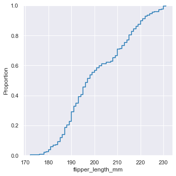

```python
sns.displot(ejemplo_penguins, x="flipper_length_mm", kind="ecdf")
```

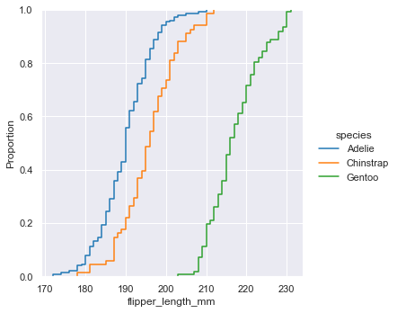

```python
sns.displot(ejemplo_penguins, x="flipper_length_mm", hue="species", kind="ecdf")
```

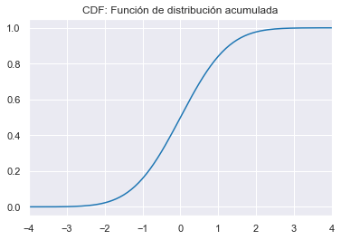

```python
## La forma tórica de la función acumulada de distribución para una distribución normal toma el siguiente patrón general:
x = np.r_[-10:10:0.1]
rv = stats.norm(0,1)   # random variate

plt.plot(x,rv.cdf(x))
plt.xlim([-4,4])
plt.title('CDF: Función de distribución acumulada')
```